# Distance Index Analysis (vignette)

2017-05-11

# Construction of Distance Index

Distance Index, będący częścią wyliczanego indeksu SPAG jest wyliczany poprzez wyznaczenie stosunku średniej odległości pomiędzy firmami do średniej odległości pomiędzy firmami w przypadku gdy byłyby rozłożone w sposób jednorodny na obszarze. Taki sposób zdefiniowania tego indeksu sprawia pewne trudności - w algorytmie korzysta się ze średniej odległości pomiędzy firmami, który ma złożoność pamięciową wynoszącą $O(n^2)$, co sprawia, że nawet dla niewielkiej liczby firm wyznaczenie wartości tego indeksu może okazać się zbyt czasochłonne dla przeciętnego komputera. Problem z czasem wyliczania indeksu wydaje się być na tyle poważny, że niezbędne jest opracowanie bardziej wydajnego sposobu jego otrzymywanie. W poniższym opracowaniu przedstawiona jest analiza otrzymywanych wartości indeksu Distance, w przypadku, gdy jest on wyliczany jedynie na pewnym podzbiorze firm.

## Funkcja Distance

Na potrzeby dalszych analiz funkcja wyliczająca indeks Distance została uproszczona, tak aby odległość w przypadku jednorodnego rozmieszczenia firm była podawana jako argument funkcji.

## Zbióry testowe.

```r
library(tidyr)
library(SPAG)
setwd("C:/Users/Max/Desktop/TestEmpiryczny")
dane<-read.csv("geoloc data.csv", header=TRUE, sep=";", dec=".")

ShapefileDF<-as.data.frame(ShapefilePoland)
region<-ShapefilePoland#[ShapefileDF$jpt_nazwa_=="lubelskie",]
newCoordinateSystem<-"+proj=longlat +datum=WGS84"
region<-spTransform(region, CRS(newCoordinateSystem))
mapDF <- fortify(region)
```

Pierwszy zestaw testowy - zbiór punktóW w jednym miejscu:

```r
TestCompanies1 <- dane[dane$SEK_PKD7 %in% c("C"),c(23,24)] #  Kategoria C 1327 firm
TestCompanies2 <- dane[dane$SEK_PKD7 %in% c("C", "M", "Q","S"),c(23,24)]
TestCompanies3 <- dane[dane$SEK_PKD7 %in% c("C", "M", "Q","S", "G", "O"),c(23,24)]
TestCompanies4 <- dane[dane$SEK_PKD7 %in% c("A"),c(23,24)]
cat(paste("Liczebność zbioru 1:", nrow(TestCompanies1), "\nLiczebność zbioru 2:",nrow(TestCompanies2),
            "\nLiczebność zbioru 3:",nrow(TestCompanies3),"\nLiczebność zbioru 4:",nrow(TestCompanies4)))
```

```
## Liczebność zbioru 1: 1374
## Liczebność zbioru 2: 5010
## Liczebność zbioru 3: 10016
## Liczebność zbioru 4: 20864
```

Drugi zestaw testowy - dwa skupiska punktów, w stosunku 1:5

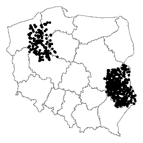

```r
df1 <- as.data.frame(cbind(TestCompanies1[1:275,1]-6,TestCompanies1[1:275,2]+2))
df2 <- TestCompanies1[276:nrow(TestCompanies1),c(1,2)]
names(df1) <- names(df2)
TestCompanies5 <- rbind(df1,df2)

ggplot() +
  geom_polygon(data=mapDF, aes(long, lat, group=group), colour='#808080', fill=NA) +
  geom_point(data=TestCompanies5, aes(coords.x1,coords.x2)) +
  theme_nothing() +
  labs(long="longitude", lat="latitude")
```

Trzeci zestaw testowy - dwa skupiska punktów, w stosunku 1:5. Liczba punktów wynosi 5010.

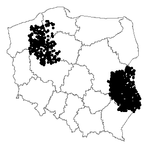

```r
df1 <- as.data.frame(cbind(TestCompanies2[1:1002,1]-6,TestCompanies2[1:1002,2]+2))
df2 <- TestCompanies2[1003:nrow(TestCompanies2),c(1,2)]
names(df1) <- names(df2)
TestCompanies6 <- rbind(df1,df2)
ggplot() +
  geom_polygon(data=mapDF, aes(long, lat, group=group), colour='#808080', fill=NA) +
  geom_point(data=TestCompanies6, aes(coords.x1,coords.x2)) +
  theme_nothing() +
  labs(long="longitude", lat="latitude")
```

Czwarty zestaw testowy - dwa skupiska punktów, w stosunku 1:5. Liczba punktów wynosi 10016

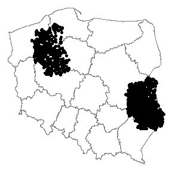

```r
df1 <- as.data.frame(cbind(TestCompanies3[1:2003,1]-6,TestCompanies3[1:2003,2]+2))
df2 <- TestCompanies3[2004:nrow(TestCompanies3),c(1,2)]
names(df1) <- names(df2)
TestCompanies7 <- rbind(df1,df2)
ggplot() +
  geom_polygon(data=mapDF, aes(long, lat, group=group), colour='#808080', fill=NA) +
  geom_point(data=TestCompanies7, aes(coords.x1,coords.x2)) +
  theme_nothing() +
  labs(long="longitude", lat="latitude")
```

Piąty zestaw testowy - dwa skupiska punktów, w stosunku 1:5. Liczba punktów wynosi 20864

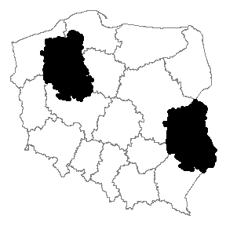

```r
df1 <- as.data.frame(cbind(TestCompanies4[1:4173,1]-6,TestCompanies4[1:4173,2]+2))
df2 <- TestCompanies4[4174:nrow(TestCompanies4),c(1,2)]
names(df1) <- names(df2)
TestCompanies8 <- rbind(df1,df2)
ggplot() +
  geom_polygon(data=mapDF, aes(long, lat, group=group), colour='#808080', fill=NA) +
  geom_point(data=TestCompanies8, aes(coords.x1,coords.x2)) +
  theme_nothing() +
  labs(long="longitude", lat="latitude")
```

Szósty zestaw testowy - dwa skupiska punktów, w stosunku 1:20. Liczba punktów wynosi 20864:

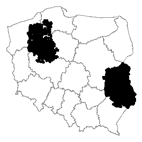

```r
df1 <- as.data.frame(cbind(TestCompanies4[1:1000,1]-6,TestCompanies4[1:1000,2]+2))
df2 <- TestCompanies4[1001:nrow(TestCompanies4),c(1,2)]
names(df1) <- names(df2)
TestCompanies9 <- rbind(df1,df2)

ggplot() +
  geom_polygon(data=mapDF, aes(long, lat, group=group), colour='#808080', fill=NA) +
  geom_point(data=TestCompanies9, aes(coords.x1,coords.x2)) +
  theme_nothing() +
  labs(long="longitude", lat="latitude")
```

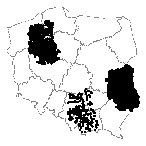

```r
df1 <- as.data.frame(cbind(TestCompanies4[1:1000,1]-6,TestCompanies4[1:1000,2]+2))
df3 <- as.data.frame(cbind(TestCompanies4[1001:1200,1]-3,TestCompanies4[1001:1200,2]-1))
df2 <- TestCompanies4[1201:nrow(TestCompanies4),c(1,2)]
names(df1) <- names(df2)
names(df3) <- names(df2)
TestCompanies10 <- rbind(df1,df2,df3)

ggplot() +
  geom_polygon(data=mapDF, aes(long, lat, group=group), colour='#808080', fill=NA) +
  geom_point(data=TestCompanies10, aes(coords.x1,coords.x2)) +
  theme_nothing() +
  labs(long="longitude", lat="latitude")
```

## Testy:

```r
listaTestow <- list(TestCompanies1,TestCompanies2,TestCompanies3,TestCompanies4,TestCompanies5,
                    TestCompanies6,TestCompanies7,TestCompanies8,TestCompanies9,TestCompanies10)

listaWolumenów <- list(100,200,500,1000)


for (numer in 1:(length(listaTestow))){
  print(paste("Iteracja:", numer))
  theoreticalDist <- spsample(region, nrow(listaTestow[[numer]]), type="regular", offset=c(0,0))
  theoreticalDist <- mean(dist(theoreticalDist@coords))
  print(paste("Odległość teoretyczna:", theoreticalDist))

  for (wolumen in 1:length(listaWolumenów)){
    chwilowaRamka <- data.frame("nazwa" = numeric(0))

    for(i in 1:1000){
      chwilowaRamka <- rbind(chwilowaRamka, calcDistanceIndex(listaTestow[[numer]], region, theoreticalDist, listaWolumenów[[wolumen]]))
    }

    assign(paste('test', numer,'FULL',listaWolumenów[[wolumen]], sep=''), chwilowaRamka )
    nazwa <- paste('test', numer,'FULL',listaWolumenów[[wolumen]], sep='')
    doZapisu <- paste0("save(",nazwa,", file='C:/Users/Max/Desktop/TestEmpiryczny/", nazwa, ".rda' )")
    eval(parse(text=doZapisu))
  }
}
```

```r
WynikiDokladneIndeksuSPAG <- data.frame("nazwa" = numeric(0))
for (numer in 1:length(listaTestow)){
  print(paste("Iteracja:", numer))
  theoreticalDist <- spsample(region, nrow(listaTestow[[numer]]), type="regular", offset=c(0,0))
  theoreticalDist <- mean(dist(theoreticalDist@coords))
  print(paste("Odległość teoretyczna:", theoreticalDist))
  nowaWart <- calcDistanceIndex(listaTestow[[numer]], region, theoreticalDist, nrow(listaTestow[[numer]]))
  WynikiDokladneIndeksuSPAG <- rbind(WynikiDokladneIndeksuSPAG, nowaWart)
  print(paste("Odległość empiryczna:", nowaWart))
  save(WynikiDokladneIndeksuSPAG, file='C:/Users/Max/Desktop/TestEmpiryczny/WynikiDokladneIndeksuSPAG.rda')

}
```

Wyniki:

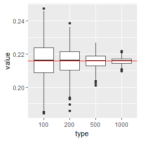

```r
library(dplyr)
library(tidyr)
setwd("C:/Users/Max/Desktop/TestEmpiryczny")
load("WynikiDokladneIndeksuSPAG.rda")
load("test1FULL100.rda")
load("test1FULL200.rda")
load("test1FULL500.rda")
load("test1FULL1000.rda")

test1x <- cbind(test1FULL100,test1FULL200,test1FULL500,test1FULL1000)
names(test1x) <- c("100", "200", "500", "1000")
test1 <- test1x %>% gather(type,value)
test1$type <- factor(as.factor(test1$type),c("100", "200", "500", "1000"))

ggplot() +
  geom_boxplot(data=test1, mapping=aes(type,value)) +
   geom_hline(yintercept = WynikiDokladneIndeksuSPAG[1,], col="red")
```

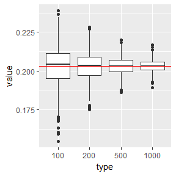

```r
setwd("C:/Users/Max/Desktop/TestEmpiryczny")
load("test2FULL100.rda")
load("test2FULL200.rda")
load("test2FULL500.rda")
load("test2FULL1000.rda")

test2x <- cbind(test2FULL100,test2FULL200,test2FULL500,test2FULL1000)
names(test2x) <- c("100", "200", "500", "1000")
test2 <- test2x %>% gather(type,value)
test2$type <- factor(as.factor(test2$type),c("100", "200", "500", "1000"))

ggplot() +
  geom_boxplot(data=test2, mapping=aes(type,value)) +
  geom_hline(yintercept = WynikiDokladneIndeksuSPAG[2,], col="red")
```

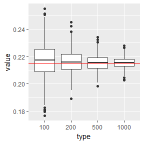

```r
setwd("C:/Users/Max/Desktop/TestEmpiryczny")
load("test3FULL100.rda")
load("test3FULL200.rda")
load("test3FULL500.rda")
load("test3FULL1000.rda")

test3x <- cbind(test3FULL100,test3FULL200,test3FULL500,test3FULL1000)
names(test3x) <- c("100", "200", "500", "1000")
test3 <- test3x %>% gather(type,value)
test3$type <- factor(as.factor(test2$type),c("100", "200", "500", "1000"))

ggplot() +
  geom_boxplot(data=test3, mapping=aes(type,value)) +
  geom_hline(yintercept = WynikiDokladneIndeksuSPAG[3,], col="red")
```

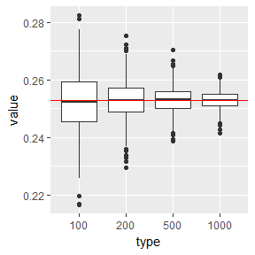

```r
setwd("C:/Users/Max/Desktop/TestEmpiryczny")
load("test4FULL100.rda")
load("test4FULL200.rda")
load("test4FULL500.rda")
load("test4FULL1000.rda")

test4x <- cbind(test4FULL100,test4FULL200,test4FULL500,test4FULL1000)
names(test4x) <- c("100", "200", "500", "1000")
test4 <- test4x %>% gather(type,value)
test4$type <- factor(as.factor(test4$type),c("100", "200", "500", "1000"))

ggplot() +
  geom_boxplot(data=test4, mapping=aes(type,value)) +
  geom_hline(yintercept = WynikiDokladneIndeksuSPAG[4,], col="red")
```

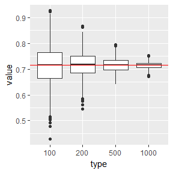

```r
setwd("C:/Users/Max/Desktop/TestEmpiryczny")
load("test5FULL100.rda")
load("test5FULL200.rda")
load("test5FULL500.rda")
load("test5FULL1000.rda")

test5x <- cbind(test5FULL100,test5FULL200,test5FULL500,test5FULL1000)
names(test5x) <- c("100", "200", "500", "1000")
test5 <- test5x %>% gather(type,value)
test5$type <- factor(as.factor(test5$type),c("100", "200", "500", "1000"))

ggplot() +
  geom_boxplot(data=test5, mapping=aes(type,value)) +
  geom_hline(yintercept = WynikiDokladneIndeksuSPAG[5,], col="red")
```

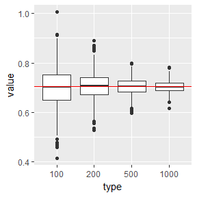

```r
setwd("C:/Users/Max/Desktop/TestEmpiryczny")
load("test6FULL100.rda")
load("test6FULL200.rda")
load("test6FULL500.rda")
load("test6FULL1000.rda")

test6x <- cbind(test6FULL100,test6FULL200,test6FULL500,test6FULL1000)
names(test6x) <- c("100", "200", "500", "1000")
test6 <- test6x %>% gather(type,value)
test6$type <- factor(as.factor(test6$type),c("100", "200", "500", "1000"))

ggplot() +
  geom_boxplot(data=test6, mapping=aes(type,value)) +
  geom_hline(yintercept = WynikiDokladneIndeksuSPAG[6,], col="red")
```

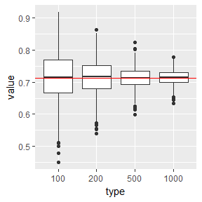

```r
setwd("C:/Users/Max/Desktop/TestEmpiryczny")
load("test7FULL100.rda")
load("test7FULL200.rda")
load("test7FULL500.rda")
load("test7FULL1000.rda")

test7x <- cbind(test7FULL100,test7FULL200,test7FULL500,test7FULL1000)
names(test7x) <- c("100", "200", "500", "1000")
test7 <- test7x %>% gather(type,value)
test7$type <- factor(as.factor(test7$type),c("100", "200", "500", "1000"))

ggplot() +
  geom_boxplot(data=test7, mapping=aes(type,value)) +
  geom_hline(yintercept = WynikiDokladneIndeksuSPAG[7,], col="red")
```

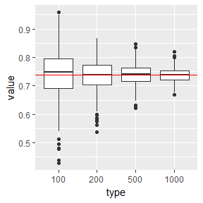

```r
setwd("C:/Users/Max/Desktop/TestEmpiryczny")
load("test8FULL100.rda")
load("test8FULL200.rda")
load("test8FULL500.rda")
load("test8FULL1000.rda")

test8x <- cbind(test8FULL100,test8FULL200,test8FULL500,test8FULL1000)
names(test8x) <- c("100", "200", "500", "1000")
test8 <- test8x %>% gather(type,value)
test8$type <- factor(as.factor(test4$type),c("100", "200", "500", "1000"))

ggplot() +
  geom_boxplot(data=test8, mapping=aes(type,value)) +
  geom_hline(yintercept = WynikiDokladneIndeksuSPAG[8,], col="red")
```

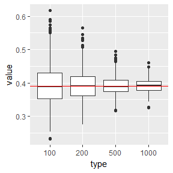

```r
setwd("C:/Users/Max/Desktop/TestEmpiryczny")
load("test9FULL100.rda")
load("test9FULL200.rda")
load("test9FULL500.rda")
load("test9FULL1000.rda")

test9x <- cbind(test9FULL100,test9FULL200,test9FULL500,test9FULL1000)
names(test9x) <- c("100", "200", "500", "1000")
test9 <- test9x %>% gather(type,value)
test9$type <- factor(as.factor(test9$type),c("100", "200", "500", "1000"))

ggplot() +
  geom_boxplot(data=test9, mapping=aes(type,value)) +
  geom_hline(yintercept = WynikiDokladneIndeksuSPAG[9,], col="red")
```

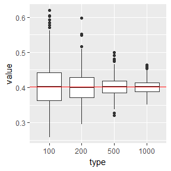

```r
setwd("C:/Users/Max/Desktop/TestEmpiryczny")
load("test10FULL100.rda")
load("test10FULL200.rda")
load("test10FULL500.rda")
load("test10FULL1000.rda")

test10x <- cbind(test10FULL100,test10FULL200,test10FULL500,test10FULL1000)
names(test10x) <- c("100", "200", "500", "1000")
test10 <- test10x %>% gather(type,value)
test10$type <- factor(as.factor(test10$type),c("100", "200", "500", "1000"))

ggplot() +
  geom_boxplot(data=test10, mapping=aes(type,value)) +
  geom_hline(yintercept = WynikiDokladneIndeksuSPAG[10,], col="red")
```

## coefficient of variation

```r
rbind(
  apply(test1x, MARGIN=2, FUN=function(x){sd(x)/mean(x)}),
  apply(test2x, MARGIN=2, FUN=function(x){sd(x)/mean(x)}),
  apply(test3x, MARGIN=2, FUN=function(x){sd(x)/mean(x)}),
  apply(test4x, MARGIN=2, FUN=function(x){sd(x)/mean(x)}),
  apply(test5x, MARGIN=2, FUN=function(x){sd(x)/mean(x)}),
  apply(test6x, MARGIN=2, FUN=function(x){sd(x)/mean(x)}),
  apply(test7x, MARGIN=2, FUN=function(x){sd(x)/mean(x)}),
  apply(test8x, MARGIN=2, FUN=function(x){sd(x)/mean(x)}),
  apply(test9x, MARGIN=2, FUN=function(x){sd(x)/mean(x)}),
  apply(test10x, MARGIN=2, FUN=function(x){sd(x)/mean(x)})
)
```

```
##              100        200        500        1000
##  [1,] 0.05128024 0.03627400 0.01917491 0.008768939
##  [2,] 0.06185384 0.04476018 0.02711190 0.017729005
##  [3,] 0.05706289 0.03775038 0.02477197 0.017904446
##  [4,] 0.03935778 0.02532130 0.01753899 0.011620572
##  [5,] 0.10551553 0.06805908 0.03801977 0.017731839
##  [6,] 0.11018586 0.07819104 0.04702835 0.032800771
##  [7,] 0.10600174 0.07412202 0.04615857 0.032807291
##  [8,] 0.10222360 0.07048766 0.04659487 0.031135797
##  [9,] 0.15089879 0.10935949 0.06988332 0.047942605
## [10,] 0.14530719 0.10386087 0.06476686 0.046518812
```

```r
mat <- matrix(rbind(
  apply(test1x, MARGIN=2, FUN=function(x){mean(x)}),
  apply(test2x, MARGIN=2, FUN=function(x){mean(x)}),
  apply(test3x, MARGIN=2, FUN=function(x){mean(x)}),
  apply(test4x, MARGIN=2, FUN=function(x){mean(x)}),
  apply(test5x, MARGIN=2, FUN=function(x){mean(x)}),
  apply(test6x, MARGIN=2, FUN=function(x){mean(x)}),
  apply(test7x, MARGIN=2, FUN=function(x){mean(x)}),
  apply(test8x, MARGIN=2, FUN=function(x){mean(x)}),
  apply(test9x, MARGIN=2, FUN=function(x){mean(x)}),
  apply(test10x, MARGIN=2, FUN=function(x){mean(x)})
), nrow=10)

for (i in 1:10){
  print(abs((mat[i,]-WynikiDokladneIndeksuSPAG[i,])/mat[i,]))
}
```

```
## [1] 1.848072e-03 9.922067e-05 2.493499e-04 3.450242e-06
## [1] 0.0008979099 0.0004957405 0.0013485849 0.0004798709
## [1] 0.0059964906 0.0032961885 0.0003406175 0.0004746046
## [1] 0.0016649357 0.0006138312 0.0005418276 0.0001634548
## [1] 6.050744e-05 1.701748e-03 2.072191e-04 4.298531e-04
## [1] 5.165468e-03 6.359216e-05 2.053787e-04 1.764568e-03
## [1] 0.002581506 0.002063943 0.001068735 0.001609233
## [1] 0.0058485497 0.0017524035 0.0007768555 0.0007608471
## [1] 0.0017776553 0.0001665222 0.0028112434 0.0010332592
## [1] 3.870523e-03 3.113714e-04 4.737728e-05 1.247435e-03
```